# ESPM 137, Lab 4: Mapping Climate Change

### Question 1 (1 pt)

**Based on the stats we calculated above and the map of temperature change from 1998 to 1999, answer the following questions:**  
**1a) What was the mean change in annual temperature across the study area? What was the range?** > mean: -0.1998639 degrees, range: -0.9362698 to 0.1710749 degrees

**1b) How would you describe, in very general terms, the spatial distribution of temperature change? (i.e. Where are there greater or lesser areas of change?)** > The distribution of temperature change is fairly consistent and negative across the landscape of California, with greater decrease in temperature change in southern regions.

### Question 2 (1 pt)

**2a) What is the spatial scale of the rasters used to calculate temperature change above in Part 2?** > grain: 0.125 degrees x 0.125 degrees (x,y) , extent: -124.625, -113 , 31.875, 44 (long_min degrees, long_max degrees, lat_min, lat_max degrees)

**2b) What is the temporal scale of the investigation performed to calculate temperature change above in Part 2?** > grain: 1 year, extent: 2 years (1998 to 1999)

## Part 3: Calculating Temperature Change Between Decades

Since there is likely a lot of temperature variation between years that might not always be related to long term temperature trends, we might want to smooth out some of the short term variation so that we can see the longer term trend. One way we could do this is by calculating averages over several years (for instance, a decade) and then comparing those longer term averages.

### Question 3 (1 pt)

**So, let’s make some decadal (10 year) averages of annual mean temperatures. In the code chunk below, create two new rasters. The first raster (avg1950s) should be the average AMTs for the 1950s (1950 to 1959), and the second raster (avg2000s) should be the average AMTs for the 2000s (2000 to 2009).** **Hint: You may want to call the rasters by their [[index]] numbers instead of their layer names.**

```r
avg1950s <- mean(AMTs[[1:10]])
avg2000s <- mean(AMTs[[51:60]])
```

We can plot the rasters you created side by side to visually compare the temperatures of the 1950s to the temperatures of the 2000s.

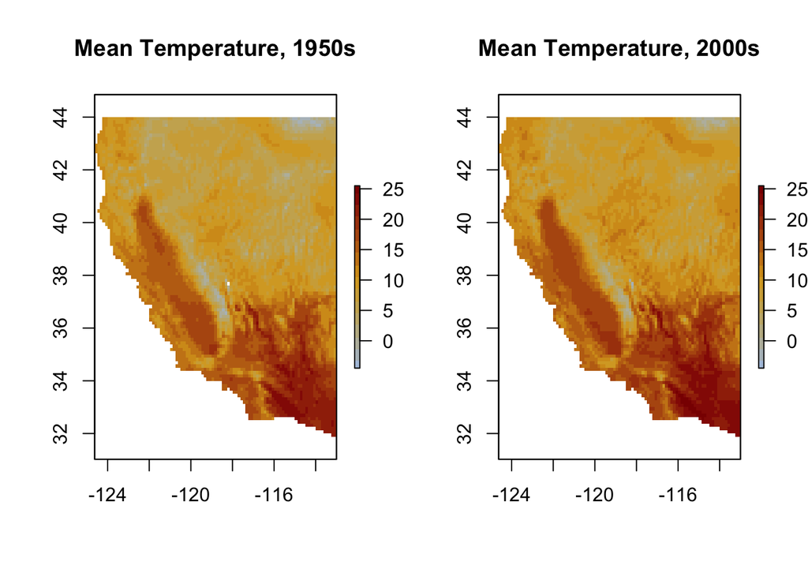

```r
par(mfrow=c(1,2))
plot(avg1950s, col=heatScheme(16), main="Mean Temperature, 1950s", zlim=c(-4.5, 25.5))
plot(avg2000s, col=heatScheme(16), main="Mean Temperature, 2000s", zlim=c(-4.5, 25.5))
```

### Question 4 (1 pt)

**Now, calculate the difference in average decadal temperatures between the 1950s and 2000s. Assign the result to a new raster named diff.1950s_2000s. Also calculate the mean and range of values on this new raster.**

```r
diff.1950s_2000s <- avg2000s - avg1950s
cellStats(diff.1950s_2000s, stat='mean')
```

```
## [1] 1.467238
```

```r
cellStats(diff.1950s_2000s, stat='range')
```

```
## [1] 0.943926 1.905793
```

> mean: [1.467238], range: [0.943926, 1.905793]

Now plot the new raster.

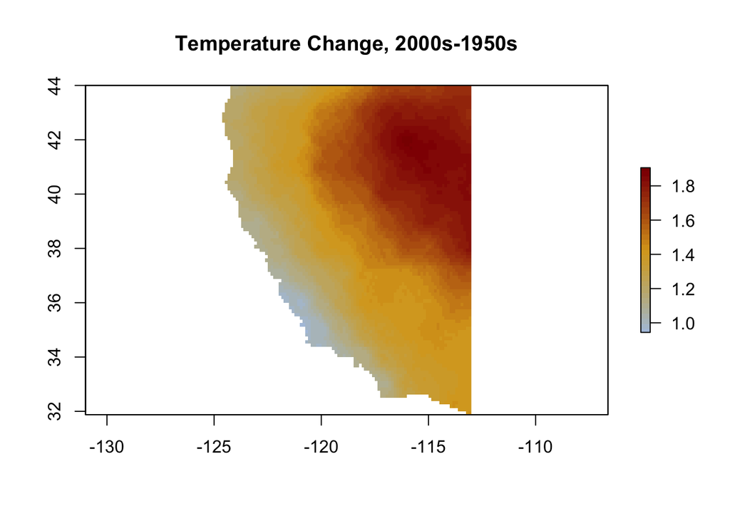

```r
plot(diff.1950s_2000s, col=heatScheme(32), main="Temperature Change, 2000s-1950s")
```

### Question 5 (2 pts)

**5a) Examine the plotted raster. How would you describe (in general terms) where there is greater or lesser temperature change?** > From the plotted raster we can see that there was greater overall change in average temperature in inland regions and less overall change near coastlines. There was an increase in average temperature overall, but inland regions warmed more than coastlines.

### Question 6 (2 pts)

**6a) What is the temporal scale of the investigation performed to calculate temperature change above in Part 3?** > grain: 10 years, extent: 60 years (1950 - 2009)

**6b) At what temporal scale does it make more sense to investigate something like climate change? Why (briefly)?** > Investigating something like climate change requires decadal or century temporal scale because that is the scale on which climate change behaves consistently. Measruing yearly changes would not be accurate because there are random fluctuations in temperature change that don’t represent long term trends well.

## Part 4: Changing the Scale of Rasters

Next, let’s take a closer look at the spatial scale of our rasters and what happens when we examine temperature change at different spatial resolutions. We’ll do this by creating a new raster of AMT with a different spatial scale.

First, we want to assign the extent and projection of our current raster stack to new objects. We’ll use these to create a new raster with the same extent and projection, which is important if we want to compare different rasters.

```r
emptyRaster <- raster(ext=my_ext, crs=my_proj, resolution=1.25)
emptyRaster
```

```
## class      : RasterLayer
## dimensions : 10, 9, 90  (nrow, ncol, ncell)
## resolution : 1.25, 1.25  (x, y)
## extent     : -124.625, -113.375, 31.5, 44  (xmin, xmax, ymin, ymax)
## crs        : +proj=longlat +datum=WGS84 +no_defs
```

Now we can use the resample() function to create rasters with the new resolution (of our emptyRaster). Let’s do this for the avg1950s and avg2000s rasters you created.

Usage resample(x, y) Arguments x Raster object to be resampled y Raster object with parameters that x should be resampled to

### Question 7 (1 pt)

**7a) We haven’t shown you an example of the resample() function before, but if you look at the Usage and Arguments required you should be able to figure it out. Here, resample the avg1950s and avg2000s rasters, and then calculate the difference between the rescaled rasters.**

```r
avg1950s.rescaled <- resample(avg1950s, emptyRaster)

avg2000s.rescaled <- resample(avg2000s, emptyRaster)

diff.newRasters <- avg2000s.rescaled - avg1950s.rescaled
```

Now, let’s plot the result.

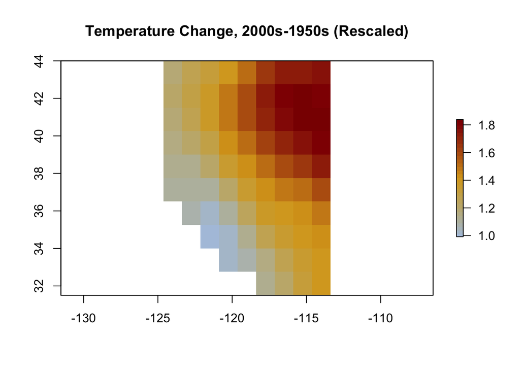

```r
plot(diff.newRasters, col=heatScheme(32), main="Temperature Change, 2000s-1950s (Rescaled)")
```

Let’s also create a matrix of latitude/longitude points, extract the values for those points (they correspond to Berkeley, Yosemite, and San Diego), and calculate the mean and range for the new raster.

```r
# Create points and extract values
pts <- matrix(c(-122.2645, -119.9012, -116.8421, 37.8727, 37.6415, 32.9542), nrow=3, ncol=2) # sample points
extract(diff.newRasters, pts) # extract values for the new raster at the sample points
```

```
## [1] 1.132868 1.217806 1.261330
```

```r
# Calculate mean and range on the diff.newRasters layer. Write in your functions for doing this here.
cellStats(diff.newRasters, stat='mean')
```

```
## [1] 1.40444
```

```r
cellStats(diff.newRasters, stat='range')
```

```
## [1] 0.9916673 1.8391445
```

**7b) How does changing the raster resolution affect what we might infer about climate change across California from 1950 to 2009? Consider the mean, range, and extracted values of the new difference raster when answering.** > Changing the raster resolution limits the amount of information we can infer about climate change across California from 1950 to 2009. In our new raster, with this larger resolution (cell size), calculated mean is smaller and the range is more limited/narrow than the original raster. Thus, any values we extract from the new raster will not be as accurate.

## Part 5: Creating a Raster Stack of Temperature Changes Through Time

Finally, we might be interested in not just the total difference in temperature between two time periods but also the changes between years over the whole time span of our study. Since we’ve been working with raster stacks and raster math today, we know that we can make a raster stack composed of raster layers that contain the difference in AMT between each year and the first layer in our stack (1950). This would give us a better sense for how temperature is changing through time.

### Question 8 (1 pt)

**In the code chunk below, create a new raster stack in which each raster is the difference in AMT between that year and the first year in the dataset (1950). Your new stack should have as many raster layers as the original AMT stack. Name your new raster stack TempChange.** **Hint: It will help to create an empty stack first, and you’ll probably want to use a for(){} loop. Also, you can use nlayers() to get the number of layers in a raster stack, and you can use the stack() function to add new rasters to an existing raster stack.**

```r
TempChange <- stack()
TempChange <- stack(TempChange, AMTs$X1950)
for(i in 2:nlayers(AMTs)) {
  new.raster = AMTs[[i]] - AMTs$X1950
  TempChange <- stack(TempChange, new.raster)
}
```

And then we can extract the values for our three points from every layer in your new raster stack and plot the values for each year at each point.

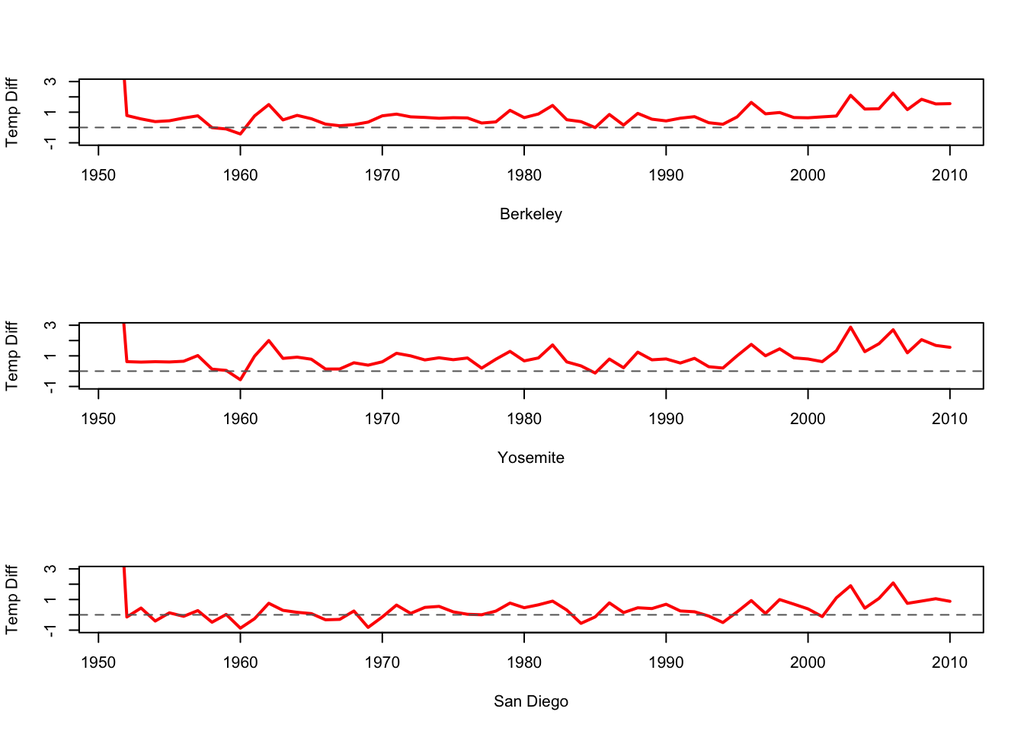

```r
# Extract temperatures from the new stack
temps <- extract(TempChange, pts)

# Plot the values for each year for each point
par(mfrow=c(3,1))
plot(temps[1,], col="red", type="l", lwd=2, ylim=c(-1,3), ylab="Temp Diff", xaxt="n", xlab="Berkeley")
axis(1,at=seq(0,60,by=10),labels=seq(1950,2010,by=10))
abline(h=0, lty=2, col="gray40")
plot(temps[2,], col="red", type="l", lwd=2, ylim=c(-1,3), ylab="Temp Diff", xaxt="n", xlab="Yosemite")
axis(1,at=seq(0,60,by=10),labels=seq(1950,2010,by=10))
abline(h=0, lty=2, col="gray40")
plot(temps[3,], col="red", type="l", lwd=2, ylim=c(-1,3), ylab="Temp Diff", xaxt="n", xlab="San Diego")
axis(1,at=seq(0,60,by=10),labels=seq(1950,2010,by=10))
abline(h=0, lty=2, col="gray40")
```

After you have finished this step you have completed the full, graded portion of the lab. If you would like an additional challenge, you can try the Part 6 section below. That section is extra, and there are no bonus points, but if you would like to test your skills and learn a little more you might want to give it a try.

Don’t forget to save your work! Save it both as an Rmd file and use the Knit option to turn it into a document to upload on bcourses (html format is preferred, but any format is acceptable).

## Extra (Part 6): Calculating Moving Averages of Mean Temperature

Finally, we might also be interested in the trajectory (or general trend) of landscape change. One way of examining this is to plot the difference in temperature (from some starting reference point) every year, as we did in Part 5. However, as we saw earlier, temperature fluctuations year to year might not be part of a broader climate trend. Another way to smooth out short term variation is to take a moving average through time. This is similar to what we did to calculate the decadal averages, but instead of calculating the averages for two set time periods, we want to calculate a multi-year average for every year in our raster stack using a moving window approach. You can think of this like taking a box and putting it down over a set of years, taking the average of those years, then sliding the whole box to one year later, taking the average of that new set of years, and repeating this process until you reach the end of the raster stack.

There are methods for statistically determining the window size for this kind of analysis, but for now let’s just pick a window size that is similar to our decadal averages. So, we’ll go with 9 years. Each window will be centered on one of the years, so a window of 9 years will have the year we’re focusing on plus 4 years in either direction. e.g. The window for 2005 will include 2001-2009.

### Question 9 (0 pts)

**This might be a little challenging, but over the last three weeks we’ve shown you all the tools you’ll need to do this. In the code chunk below, create a new raster stack made up of the 9-year moving averages for the rasters in our AMTs stack. Because we need to have 4 years in each direction (and our AMTs stack starts with 1950 and ends with 2009), the first raster in your new stack should be the average centered on 1954 (1950-1958), and the last will be centered on 2005. Name the new stack MovingAvg.** Hint: It will help to create an empty stack first, and you’ll probably want to use a for(){} loop. Also, you can use nlayers() to get the number of layers in a raster stack, and you can use the stack() function to add new rasters to an existing raster stack.